# Prediction

Anna Hołdyńska

14th June 2022

## Table of Contents

1. **Introduction**
2. **Linear Regression**
3. **Polynomial Regression**
4. **Multiple Regression**
5. **Logistic Regression**
6. **Exercises**
7. **References**

## Introduction

Before we start to focus on prediction, we should take a closer look at the regression term. Regression is a method that allows us to study a relationship between the variables. We can use this knowledge to predict unknown values based on others’ known. In practice, we look for a relation between the independent variable $X$ and the dependent variable $Y$. This relationship can be used to predict the value of $Y$ depending on $X$. For example, the price of a house depends on the number of rooms. In `R` we write it as `Price ~ Rooms`.

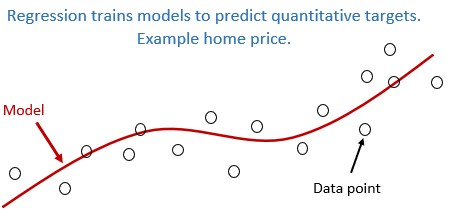

We build a regression model that we will use later for prediction. From a mathematical point of view, we want to create a regression function and try to fit it to our data. We are going to talk about different types of regression. For example, in linear regression our function will be a linear function and in polynomial regression, a polynomial.

## Linear Regression

Information about linear regression can be found in the “Statistical tests” lecture. We will see the use of linear regression in practice.

### Example: Tuberculosis cases

Example below illustrates number of tuberculosis cases in 1995-2002. Number of cases was reported per 100 000 people. We assume a linear relationship between the year and the cases. We will build a regression model and try to predict the number of cases in 2003.  
In the beginning, we create a data frame.

```r
year <- 1995:2002
cases <- c(39.7, 38.2, 34.7, 33.1, 30.1, 28.4, 26.3, 24.7)
data.set <- data.frame(year, cases)
```

A good approach is to draw our data and see how it looks on the graph. This may help select a type of regression.  
We can see in the plot below that data is arranged linearly.

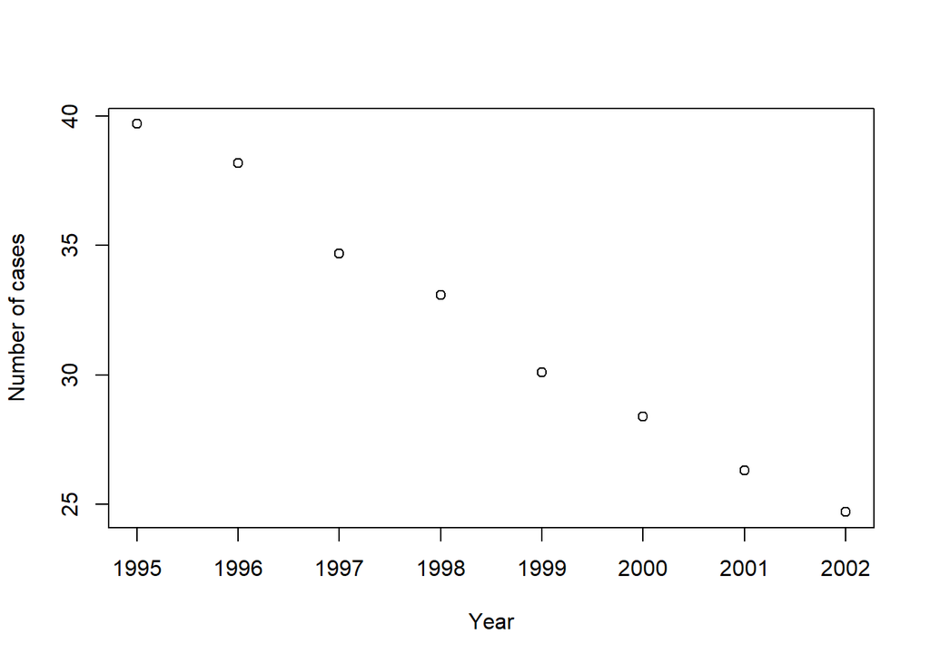

```r
plot(data.set, pch = 21, xlab = "Year", ylab = "Number of cases")
```

We create a linear regression model.

```r
model.lm <- lm(cases ~ year, data = data.set)
```

We add a regression line to our plot using the `abline()` function.

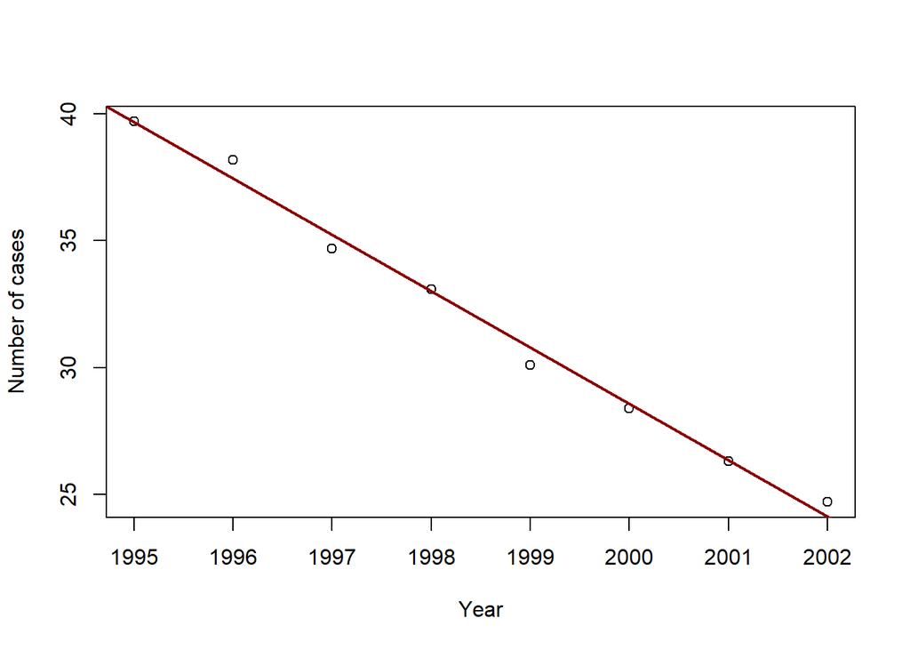

```r
plot(data.set, pch = 21, xlab = "Year", ylab = "Number of cases")
abline(model.lm, col = 'darkred', lwd = 2)
```

The `Summary()` function displays the statistics of our created model.  
We can see the values of quartiles (`1Q` and `3Q`), minimum (`Min`), maximum (`Max`), and median (`Median`) for the residuals.  
The directional factor (`Estimate: -2.21905`) shows that year over year, the number of cases decreased by 2.22.  
The standard error (`Std. Error`), the value of t statistic (`t value`), and p-value (`Pr(>|t|)`) are given for each of the estimators. With p-value, we can tell if the `year` parameter is statistically significant. The number `1.65e-07` is less than 0.05, which means we reject the null hypothesis. Time significantly affects the number of cases.  
We are also interested in the coefficient of determination $R^2$ (`Multiple R-squared`) and the adjusted coefficient of determination $R^2$ (`Adjusted R-squared`). When we have more than one independent variables in our model, like in multiple regression, we pay more attention to `Adjusted R-squared`, but in linear regression we look at `Multiple R-squared`. It is assumed that a good fit of the model to the data is when the coefficient is greater than 60%. We have to remember that measuring the quality of a model using the coefficient of determination makes no sense when we remove `Intercept` parameter from the model. Removing `Intercept` parameter depends on researcher and the problem. In our examples, we will not remove this parameter. However, if we ever wanted to remove it, we should measure the quality of the model using other measures, for example MAE, MAPE or RMSE. Each of these measures is described by a mathematical formula that we use in the `R` code. The smaller MAE/MAPE/RMSE value, the better the model. 0 means the model is perfect.

```r
MAE = mean(abs(resid(model.lm)))
MAPE = mean(abs(resid(model.lm)) / abs(data.set$cases))
RMSE = sqrt(mean(resid(model.lm)^2))
```

If we want to remove `Intercept` parameter, in `lm()` function, we have to type `cases ~ year - 1` instead of `cases ~ year`.

```r
summary(model.lm)
```

```
##
## Call:
## lm(formula = cases ~ year, data = data.set)
##
## Residuals:
##      Min       1Q   Median       3Q      Max
## -0.69048 -0.26071 -0.00952  0.20952  0.75238
##
## Coefficients:
##               Estimate Std. Error t value Pr(>|t|)
## (Intercept) 4466.66667  163.40805   27.33 1.58e-07 ***
## year          -2.21905    0.08177  -27.14 1.65e-07 ***
## ---
## Signif. codes:  0 '***' 0.001 '**' 0.01 '*' 0.05 '.' 0.1 ' ' 1
##
## Residual standard error: 0.5299 on 6 degrees of freedom
## Multiple R-squared:  0.9919, Adjusted R-squared:  0.9906
## F-statistic: 736.5 on 1 and 6 DF,  p-value: 1.654e-07
```

Finally, we will try to predict the number of cases in 2003. A good choice to do this will be the `predict()` function.

```r
predict(model.lm, list(year = 2003))
```

```
##        1
## 21.91429
```